# Titanic_ML:

Ronen Saviz, ID 205688690  
https://www.kaggle.com/savizronen

## Introduction

- This competition is about trying to predict if a passenger survived the sinking of the Titanic or not.
- Starting from dataset understanding, up until machine learning model training and evaluation.

#### Data Description

- Dataset Summary - Titanic passenger details, including a column if the survived passenger survived or not.
- Index Column (Instance of what we want to predict for) - `PassengerId`.
- Target Column (What we want to predict for each element in Index Column) - `Survived`.
- Features - Remaining Columns.

## Tasks

- Our target is to learn the "t" function.
- This case is about binary classification (Survived or not), therefore it will be performed by using "Logistic Regression".
- After the learning process, a new data will be tested with our model to determine who's going to be survived and who isn't.

**Imports:**

```python
#numpy,pandas,seaborn,matplotlib imports
import numpy as np
import pandas as pd
import seaborn as sns
import matplotlib.pyplot as plt

# sklearn imports
from sklearn import preprocessing
from sklearn.pipeline import make_pipeline
from sklearn.metrics import confusion_matrix
from sklearn.linear_model import SGDClassifier
from sklearn.preprocessing import OneHotEncoder
from sklearn.neural_network import MLPClassifier
from sklearn.preprocessing import StandardScaler
from sklearn.linear_model import LogisticRegression
from sklearn.model_selection import train_test_split
from sklearn.metrics import classification_report,accuracy_score
```

**Reading the dataset:**

```python
train = pd.read_csv('/home/linuxu/Desktop/titanic-ml-task-1-205688690/train.csv') #Reading the data for training.
test = pd.read_csv('/home/linuxu/Desktop/titanic-ml-task-1-205688690/test.csv') #Reading the data for testing.
test_ids = test["PassengerId"] #Save the PassengerId to predict the data.
```

```python
#Show the dataset.
train.head()
```

|  | PassengerId | Survived | Pclass | Name | Sex | Age | SibSp | Parch | Ticket | Fare | Cabin | Embarked |
| --- | --- | --- | --- | --- | --- | --- | --- | --- | --- | --- | --- | --- |
| 0 | 1 | 0 | 3 | Braund, Mr. Owen Harris | male | 22.0 | 1 | 0 | A/5 21171 | 7.2500 | NaN | S |
| 1 | 2 | 1 | 1 | Cumings, Mrs. John Bradley (Florence Briggs Th... | female | 38.0 | 1 | 0 | PC 17599 | 71.2833 | C85 | C |
| 2 | 3 | 1 | 3 | Heikkinen, Miss. Laina | female | 26.0 | 0 | 0 | STON/O2. 3101282 | 7.9250 | NaN | S |
| 3 | 4 | 1 | 1 | Futrelle, Mrs. Jacques Heath (Lily May Peel) | female | 35.0 | 1 | 0 | 113803 | 53.1000 | C123 | S |
| 4 | 5 | 0 | 3 | Allen, Mr. William Henry | male | 35.0 | 0 | 0 | 373450 | 8.0500 | NaN | S |

```python
# Prints the amount of empty values in each value.
def count_empty_values_in_each_column(df):
    code = "len(np.where(df[column].isnull())[0])"
    for column in df.columns:
        print(f'`{column}`: {eval(code)}')
# Prints the amount of empty values in each value in train and test of the ML.
def print_count_empty_values_in_each_column(train,test):
    print(" Data train empty values in each column:")
    count_empty_values_in_each_column(train)
    print("-----------------")
    print(" Data test empty values in each column:")
    count_empty_values_in_each_column(test)
```

```python
#Print count of each value before cleaning.
print_count_empty_values_in_each_column(train,test)
```

```
 Data train empty values in each column:
`PassengerId`: 0
`Survived`: 0
`Pclass`: 0
`Name`: 0
`Sex`: 0
`Age`: 177
`SibSp`: 0
`Parch`: 0
`Ticket`: 0
`Fare`: 0
`Cabin`: 687
`Embarked`: 2
-----------------
 Data test empty values in each column:
`PassengerId`: 0
`Pclass`: 0
`Name`: 0
`Sex`: 0
`Age`: 86
`SibSp`: 0
`Parch`: 0
`Ticket`: 0
`Fare`: 1
`Cabin`: 327
`Embarked`: 0
```

```python
#Dictionary of Title.
Title_Dictionary ={
    "Capt": "officer",
    "Col": "officer",
    "Major":"officer",
    "Jonkheer":"Royalty",
    "Don":"Royalty",
    "Dona":"Royalty",
    "Sir":"Royalty",
    "Dr":"officer",
    "Rev":"officer",
    "the Countess":"Royalty",
    "Mme":"Mrs",
    "Mlle":"Miss",
    "Ms":"Mrs",
    "Mr":"Mr",
    "Mrs":"Mrs",
    "Miss":"Miss",
    "Master":"Master",
    "Lady":"Royalty",
}
```

**Cleaning operations:**

```python
#Changes the names to titles.
def title_name(data):
    return  Title_Dictionary[data['Name'].split(',')[1].split('.')[0].strip()]

# Filling all cols in a mean value.
def filling_cols_in_a_mean_value(data,cols):
    for col in cols:
        data[col].fillna(data[col].mean(), inplace=True)
    return data

# Filling the empty value column with 'U' (Unknown).
def filling_empty_value_in_unknown_val(data,value):
    data[value].fillna('U', inplace=True)
    return data

#Drop selected features.
def drop_features(data,features):
    return data.drop(features, axis=1)

#Keeping the first letter in a feature.
def Keeping_the_first_letter_in_a_feature(data,feature):
    for i in range(len(data[feature])):
         data[feature].replace(data[feature][i], data[feature][i][0], inplace=True)
    return data
```

```python
#Cleaning the data.
def clean(data):

    #Creation a Title for every person.
    data['Title']=data.apply(title_name, axis = 1)

    filling_empty_value_in_unknown_val(data,"Cabin")

    #Filling the empty cols with 'U' (Unknown).
    cols = ["Fare", "Age","SibSp", "Parch"]
    data = filling_cols_in_a_mean_value(data,cols)

    #Keeping the first letter, which makes the column's values to be divided by zones.
    Keeping_the_first_letter_in_a_feature(data,"Cabin")

    #Drop all the unimportant features.
    unimportant_features=["PassengerId", "Ticket","Embarked","Name"]
    data = drop_features(data,unimportant_features)

    return data

train = clean(train)
test = clean(test)
```

```python
#Print count of each value after cleaning.
print_count_empty_values_in_each_column(train,test)
```

```
 Data train empty values in each column:
`Survived`: 0
`Pclass`: 0
`Sex`: 0
`Age`: 0
`SibSp`: 0
`Parch`: 0
`Fare`: 0
`Cabin`: 0
`Title`: 0
-----------------
 Data test empty values in each column:
`Pclass`: 0
`Sex`: 0
`Age`: 0
`SibSp`: 0
`Parch`: 0
`Fare`: 0
`Cabin`: 0
`Title`: 0
```

**All graphs prints:**

```python
#Graph displot that depicting all survivors by age.
def graph_description_survived_by_ages(data):
    sns.displot(x='Age', data=data, col='Survived' ,hue='Survived')
    plt.show()

#Graph countplot that depicting all survivors by gender.
def graph_description_survived_by_gender(data):
    sns.countplot(data=data, x='Survived', hue='Sex')
    plt.show()

#Graph countplot that depicting all survivors by title.
def graph_description_survived_by_Title(data):
    sns.countplot(data=data, x='Survived', hue='Title')
    plt.show()

#Graph countplot that depicting all survivors by cabin.
def graph_description_survived_by_Cabin(data):
    sns.countplot(data=data, x='Survived', hue='Cabin')
    plt.show()

#Graph countplot that depicting all survivors by count.
def graph_description_survived_count(data):
    sns.countplot(data=data, x="Survived")
    plt.show()

#Graph countplot that depicting all survivors by pclass.
def graph_description_survived_by_pclass(data):
    sns.countplot(data=data, x='Survived', hue='Pclass')
    plt.show()

#Graph countplot that depicting all survivors by sibsp.
def graph_description_survived_by_sibsp(data):
    sns.countplot(data=data, x='Survived', hue='SibSp')
    plt.show()

#Graph countplot that depicting all survivors by parch.
def graph_description_survived_by_parch(data):
    sns.countplot(data=data, x='Survived', hue='Parch')
    plt.show()

#Graph heatmap that depicting all survivors by values.
def graph_heatmap(data):
    plt.figure(figsize=(13,8))
    cor = np.abs(data.corr())
    sns.heatmap(cor, annot=True, cmap=plt.cm.Blues, vmin=-1, vmax=1)
    plt.show()
```

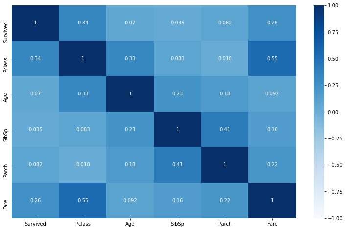

```python
#show heatmap graph.
graph_heatmap(train)
```

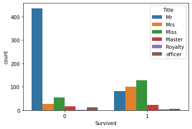

```python
graph_description_survived_by_Title(train)
```

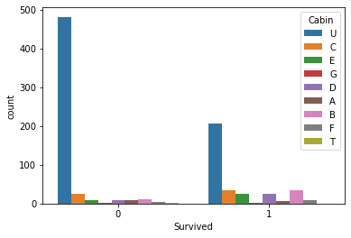

```python
graph_description_survived_by_Cabin(train)
```

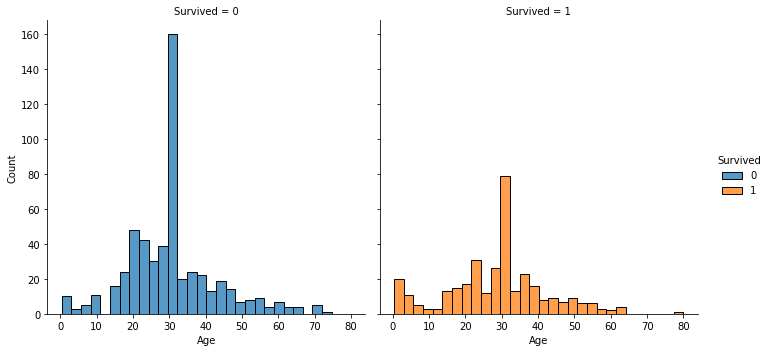

```python
graph_description_survived_by_ages(train)
```

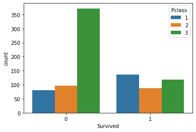

```python
graph_description_survived_by_pclass(train)
```

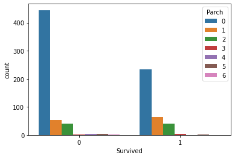

```python
graph_description_survived_by_parch(train)
```

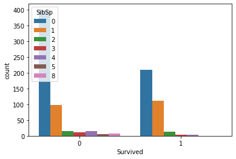

```python
graph_description_survived_by_sibsp(train)
```

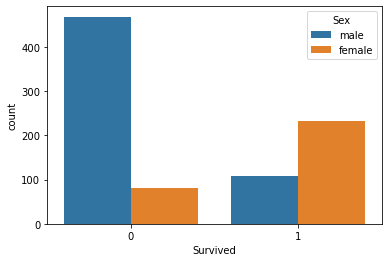

```python
graph_description_survived_by_gender(train)
```

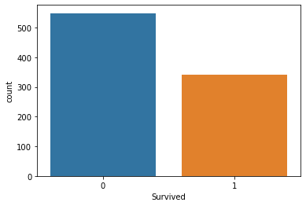

```python
graph_description_survived_count(train)
```

**Encoding features by one hot encoder:**

```python
#Encoding sex by one hot encoder.
def one_hot_encoder_sex(data,encoder):
    encoder_title = pd.DataFrame(encoder.fit_transform(data[['Sex']]).toarray())
    encoder_title.columns = ['Female' ,'Male']
    data = data.join(encoder_title)
    return data

#Encoding Title by one hot encoder.
def one_hot_encoder_title(data,encoder):
    encoder_title = pd.DataFrame(encoder.fit_transform(data[['Title']]).toarray())
    encoder_title.columns = ['Master', 'Miss', 'Mr' ,'Mrs', 'Royalty' ,'Officer']
    data = data.join(encoder_title)
    return data

#Encoding Cabin by one hot encoder.
def one_hot_encoder_cabin(data,encoder):
    le = preprocessing.LabelEncoder()
    data['Cabin']= le.fit_transform(data['Cabin'])
    return data
```

**Prepare all values for prediction:**

```python
#Activation of all encoder operations.
def one_hot_encoder(data):
    encoder = OneHotEncoder(handle_unknown='ignore')
    data=one_hot_encoder_sex(data,encoder)
    data=one_hot_encoder_title(data,encoder)
    one_hot_encoder_cabin(data,encoder)
    data=data.drop('Title', axis=1)
    return  data.drop('Sex', axis=1)

train=one_hot_encoder(train)
test=one_hot_encoder(test)
train
```

|  | Survived | Pclass | Age | SibSp | Parch | Fare | Cabin | Female | Male | Master | Miss | Mr | Mrs | Royalty | Officer |
| --- | --- | --- | --- | --- | --- | --- | --- | --- | --- | --- | --- | --- | --- | --- | --- |
| 0 | 0 | 3 | 22.000000 | 1 | 0 | 7.2500 | 8 | 0.0 | 1.0 | 0.0 | 0.0 | 1.0 | 0.0 | 0.0 | 0.0 |
| 1 | 1 | 1 | 38.000000 | 1 | 0 | 71.2833 | 2 | 1.0 | 0.0 | 0.0 | 0.0 | 0.0 | 1.0 | 0.0 | 0.0 |
| 2 | 1 | 3 | 26.000000 | 0 | 0 | 7.9250 | 8 | 1.0 | 0.0 | 0.0 | 1.0 | 0.0 | 0.0 | 0.0 | 0.0 |
| 3 | 1 | 1 | 35.000000 | 1 | 0 | 53.1000 | 2 | 1.0 | 0.0 | 0.0 | 0.0 | 0.0 | 1.0 | 0.0 | 0.0 |
| 4 | 0 | 3 | 35.000000 | 0 | 0 | 8.0500 | 8 | 0.0 | 1.0 | 0.0 | 0.0 | 1.0 | 0.0 | 0.0 | 0.0 |
| ... | ... | ... | ... | ... | ... | ... | ... | ... | ... | ... | ... | ... | ... | ... | ... |
| 886 | 0 | 2 | 27.000000 | 0 | 0 | 13.0000 | 8 | 0.0 | 1.0 | 0.0 | 0.0 | 0.0 | 0.0 | 0.0 | 1.0 |
| 887 | 1 | 1 | 19.000000 | 0 | 0 | 30.0000 | 1 | 1.0 | 0.0 | 0.0 | 1.0 | 0.0 | 0.0 | 0.0 | 0.0 |
| 888 | 0 | 3 | 29.699118 | 1 | 2 | 23.4500 | 8 | 1.0 | 0.0 | 0.0 | 1.0 | 0.0 | 0.0 | 0.0 | 0.0 |
| 889 | 1 | 1 | 26.000000 | 0 | 0 | 30.0000 | 2 | 0.0 | 1.0 | 0.0 | 0.0 | 1.0 | 0.0 | 0.0 | 0.0 |
| 890 | 0 | 3 | 32.000000 | 0 | 0 | 7.7500 | 8 | 0.0 | 1.0 | 0.0 | 0.0 | 1.0 | 0.0 | 0.0 | 0.0 |

891 rows × 15 columns

**Apply hypers on the data:**

```python
#Calculating the price of a class ticket.
def fare_per_pclass(data):
    return data['Fare']/data['Pclass']

#Check if a person has a family.
def has_family(data):
    has_family=1 if  ((data['SibSp'] + data['Parch'])  > 0) else 0
    return has_family

#classification a person age range.
def age_range(data):
    if 0 <= data['Age'] <= 16:
        age_range = 0
    if 16 < data['Age'] <= 32:
        age_range = 1
    if 32 < data['Age'] <= 48:
        age_range = 2
    if 48 < data['Age'] <= 64:
        age_range = 3
    if 64 < data['Age']:
        age_range = 4
    return age_range

#Update the data by hypers.
def apply_hypers(data):
    data['Family'] = data.apply(has_family, axis = 1)
    data['FarePerPclass'] = data.apply(fare_per_pclass, axis = 1)
    data['Age_range'] = data.apply(age_range, axis = 1)

apply_hypers(train)
apply_hypers(test)
```

```python
#show the data after the hypers.
train.head(20)
```

|  | Survived | Pclass | Age | SibSp | Parch | Fare | Cabin | Female | Male | Master | Miss | Mr | Mrs | Royalty | Officer | Family | FarePerPclass | Age_range |
| --- | --- | --- | --- | --- | --- | --- | --- | --- | --- | --- | --- | --- | --- | --- | --- | --- | --- | --- |
| 0 | 0 | 3 | 22.000000 | 1 | 0 | 7.2500 | 8 | 0.0 | 1.0 | 0.0 | 0.0 | 1.0 | 0.0 | 0.0 | 0.0 | 1 | 2.416667 | 1 |
| 1 | 1 | 1 | 38.000000 | 1 | 0 | 71.2833 | 2 | 1.0 | 0.0 | 0.0 | 0.0 | 0.0 | 1.0 | 0.0 | 0.0 | 1 | 71.283300 | 2 |
| 2 | 1 | 3 | 26.000000 | 0 | 0 | 7.9250 | 8 | 1.0 | 0.0 | 0.0 | 1.0 | 0.0 | 0.0 | 0.0 | 0.0 | 0 | 2.641667 | 1 |
| 3 | 1 | 1 | 35.000000 | 1 | 0 | 53.1000 | 2 | 1.0 | 0.0 | 0.0 | 0.0 | 0.0 | 1.0 | 0.0 | 0.0 | 1 | 53.100000 | 2 |
| 4 | 0 | 3 | 35.000000 | 0 | 0 | 8.0500 | 8 | 0.0 | 1.0 | 0.0 | 0.0 | 1.0 | 0.0 | 0.0 | 0.0 | 0 | 2.683333 | 2 |
| 5 | 0 | 3 | 29.699118 | 0 | 0 | 8.4583 | 8 | 0.0 | 1.0 | 0.0 | 0.0 | 1.0 | 0.0 | 0.0 | 0.0 | 0 | 2.819433 | 1 |
| 6 | 0 | 1 | 54.000000 | 0 | 0 | 51.8625 | 4 | 0.0 | 1.0 | 0.0 | 0.0 | 1.0 | 0.0 | 0.0 | 0.0 | 0 | 51.862500 | 3 |
| 7 | 0 | 3 | 2.000000 | 3 | 1 | 21.0750 | 8 | 0.0 | 1.0 | 1.0 | 0.0 | 0.0 | 0.0 | 0.0 | 0.0 | 1 | 7.025000 | 0 |
| 8 | 1 | 3 | 27.000000 | 0 | 2 | 11.1333 | 8 | 1.0 | 0.0 | 0.0 | 0.0 | 0.0 | 1.0 | 0.0 | 0.0 | 1 | 3.711100 | 1 |
| 9 | 1 | 2 | 14.000000 | 1 | 0 | 30.0708 | 8 | 1.0 | 0.0 | 0.0 | 0.0 | 0.0 | 1.0 | 0.0 | 0.0 | 1 | 15.035400 | 0 |
| 10 | 1 | 3 | 4.000000 | 1 | 1 | 16.7000 | 6 | 1.0 | 0.0 | 0.0 | 1.0 | 0.0 | 0.0 | 0.0 | 0.0 | 1 | 5.566667 | 0 |
| 11 | 1 | 1 | 58.000000 | 0 | 0 | 26.5500 | 2 | 1.0 | 0.0 | 0.0 | 1.0 | 0.0 | 0.0 | 0.0 | 0.0 | 0 | 26.550000 | 3 |
| 12 | 0 | 3 | 20.000000 | 0 | 0 | 8.0500 | 8 | 0.0 | 1.0 | 0.0 | 0.0 | 1.0 | 0.0 | 0.0 | 0.0 | 0 | 2.683333 | 1 |
| 13 | 0 | 3 | 39.000000 | 1 | 5 | 31.2750 | 8 | 0.0 | 1.0 | 0.0 | 0.0 | 1.0 | 0.0 | 0.0 | 0.0 | 1 | 10.425000 | 2 |
| 14 | 0 | 3 | 14.000000 | 0 | 0 | 7.8542 | 8 | 1.0 | 0.0 | 0.0 | 1.0 | 0.0 | 0.0 | 0.0 | 0.0 | 0 | 2.618067 | 0 |
| 15 | 1 | 2 | 55.000000 | 0 | 0 | 16.0000 | 8 | 1.0 | 0.0 | 0.0 | 0.0 | 0.0 | 1.0 | 0.0 | 0.0 | 0 | 8.000000 | 3 |
| 16 | 0 | 3 | 2.000000 | 4 | 1 | 29.1250 | 8 | 0.0 | 1.0 | 1.0 | 0.0 | 0.0 | 0.0 | 0.0 | 0.0 | 1 | 9.708333 | 0 |
| 17 | 1 | 2 | 29.699118 | 0 | 0 | 13.0000 | 8 | 0.0 | 1.0 | 0.0 | 0.0 | 1.0 | 0.0 | 0.0 | 0.0 | 0 | 6.500000 | 1 |
| 18 | 0 | 3 | 31.000000 | 1 | 0 | 18.0000 | 8 | 1.0 | 0.0 | 0.0 | 0.0 | 0.0 | 1.0 | 0.0 | 0.0 | 1 | 6.000000 | 1 |
| 19 | 1 | 3 | 29.699118 | 0 | 0 | 7.2250 | 8 | 1.0 | 0.0 | 0.0 | 0.0 | 0.0 | 1.0 | 0.0 | 0.0 | 0 | 2.408333 | 1 |

**EDA – Essential Data Analysis:**

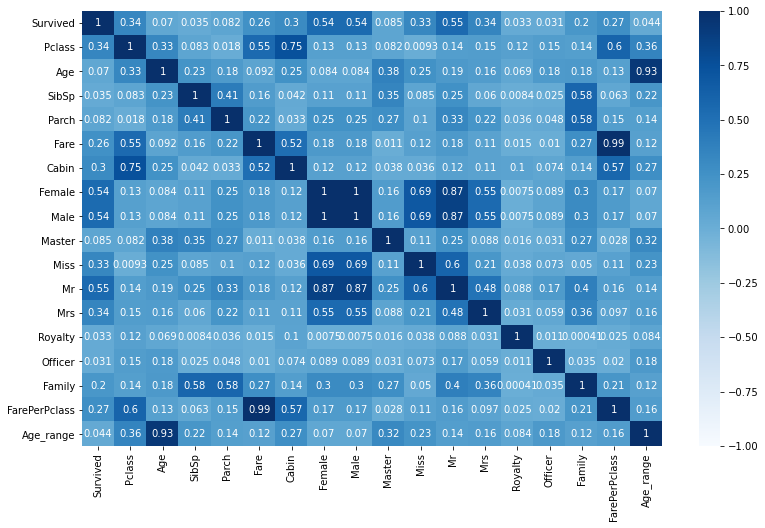

```python
#show heatmap graph.
graph_heatmap(train)
```

```python
# detach the target values from the input data.
y = train["Survived"]
x = train.drop("Survived", axis=1)

# Split the data, dividing into 70-30 percent 70 train 30 test.
train_x, val_x, train_y, val_y = train_test_split(x, y, test_size=0.3, random_state=42)
```

## Predict:

```python
# #Using by Logistic Regression to prediction.
lr = LogisticRegression(random_state=42, solver="liblinear")
lr.fit(train_x, train_y)
lr_predict = lr.predict(val_x)

# #Using by SGD to prediction.
sgd = make_pipeline(StandardScaler(),SGDClassifier(max_iter=500,random_state=42))
sgd.fit(train_x, train_y)
sgd_predict = sgd.predict(val_x)
```

## Prints the Prediction value by class of sklearn.

```python
accuracy = accuracy_score(val_y, lr_predict)
print('ML model LR accuracy - ', accuracy)

accuracy = accuracy_score(val_y, sgd_predict)
print('ML model SGD accuracy - ', accuracy)
```

```
ML model LR accuracy -  0.8246268656716418
ML model SGD accuracy -  0.7835820895522388
```

```python
#The best prediction between Logistic Regression and SGD.
predict_test = lr.predict(test)
```

```python
# # Creating submission to the competition.
submission = pd.DataFrame({"PassengerId": test_ids.values,"Survived": predict_test})
submission.to_csv("submission.csv", index=False)
submission
```

|  | PassengerId | Survived |
| --- | --- | --- |
| 0 | 892 | 0 |
| 1 | 893 | 1 |
| 2 | 894 | 0 |
| 3 | 895 | 0 |
| 4 | 896 | 1 |
| ... | ... | ... |
| 413 | 1305 | 0 |
| 414 | 1306 | 1 |
| 415 | 1307 | 0 |
| 416 | 1308 | 0 |
| 417 | 1309 | 1 |

418 rows × 2 columns

## Summary:

- I analyze the information using the graphs that can be seen in the project to predict the survival feature.
- I combination of features That had a high correlation with survival feature to reach the highest prediction.
- Distribution of titles by status ['Master', 'Miss', 'Mr' ,'Mrs', 'Royalty' ,'Officer'].

#### Hyper parameter that I used:

- Has a family for a person yes or no.
- Relationship between the price of the ticket and the class.
- Classification by age group.

## References:

https://www.kaggle.com/code/algord/titanic-logistic-regression

https://www.kaggle.com/code/uyeanil/titanic-simple-ml-workflow-gradient-boosting

https://towardsdatascience.com/kaggle-titanic-machine-learning-model-top-7-fa4523b7c40

https://www.kaggle.com/code/karthikbhandary2/titanic-predictions-with-different-models

[figure not shown]

[figure not shown]